# OGS-00009 rebuilt against OGS-00010

The 0.2.0 ukb-b Reference-Completed Store against the 0.1.0 one it replaces · size, structure, query time, MR controls, regions and observed-cell fidelity

Published

October 24, 2026

**ImportantWhat changed, and the headline numbers**

The rebuilt **OGS-00009** replaces **OGS-00010**. They are both Reference-Completed UK Biobank `ukb-b` Dense Stores, and they differ in **five independent ways**. Every section below says which of the five it measures:

1. **Membership**: 490 Analyses added, 0 removed (2,514 against 2,024).
2. **Completion panel**: the UKB EUR LD panel (ukb-hg38-eur-ld) (9,847,807 panel variants) against the HGDP+1kGP hg38 EUR panel (9,782,961).
3. **hg19 lift**: opengwas/opengwasdb#288 projects reverse-strand variants onto the hg38 strand, which renames 9,420 observed variants and re-orients 1,861 reverse-strand palindromes.
4. **Format**: 0.2.0 (Zarr v3, inner chunk [1000, 64], shard [100000, 1024]) against 0.1.0 (Zarr v2, [1000, 1000] chunks).
5. **Identity model**: single-id (`store_id` OGS-00009, `release_id` OGS-00009-completed) against a two-id child (`store_id` OGS-00009, `release_id` OGS-00010).
- **Build collisions, both Stores:** 8 rows × 2,514 Analyses (20,112 cells, 16,818 observed) in the new OGS-00009, and 5 rows × 2,024 Analyses (10,120 cells, 8,864 observed) in the old OGS-00010, hold one of two colliding source variants’ statistics (opengwas/opengwasdb#325). See Build collisions.
- **Size:** 64.69 GB against 49.33 GB (1.31x), **2.299** against **1.799 bytes per cell**. The new Store holds 28.13 bn cells against 27.43 bn, and fewer of them are empty.
- **Query time** (median of 7 warm calls): one Analysis genome-wide, observed cells only, takes 7.76 s (7,578,648 results) against 26.79 s (7,578,651 results). With all of each Store’s own cells, it takes 8.15 s (9,975,895 results) against 27.23 s (11,229,918 results). A PheWAS over the shared Analyses takes 31.5 ms (2,024 results) against 30.9 ms (2,020 results).
- **MR, observed-only variants:** 3 of 3 positive controls keep their sign and their significance across the Stores: bmi_chd +0.0132 (591 instruments) against +0.0132 (591), agreeing to 5 significant figures; ldl_chd +0.1497 (34 instruments) against +0.1497 (34), agreeing to 5 significant figures; smoking_lung -0.0016 (54 instruments) against -0.0016 (54), agreeing to 4 significant figures.
- **Observed-cell fidelity**, by ALID over the 2,024 shared Analyses, in two strata that overlap:
  - 579,763,142 old observed cells at 500,004 variants in seeded windows (5.1% of the observed axis);
  - 14,190,874 cells at every observed variant the lift could have touched and at every build-collision row.

  **0 cells are unexplained** in either stratum. That holds beside **the cells at build collisions (d)**: 18,120 in the second stratum (1,967 of them also fall in the windows). In the second stratum, 2,214,318 cells are re-oriented by opengwas/opengwasdb#288 (a), and 11,270,573 sit under a variant that only one Store spells that way (b).

## The two Stores

|  | OGS-00009 · 0.2.0 | OGS-00010 · 0.1.0 |
| --- | --- | --- |
| Store path | `/data/opengwasdb/stores/OGS-00009/store.opengwasdb` | `/data/opengwasdb/stores/OGS-00010/store.opengwasdb` |
| `store_id` / `release_id` | OGS-00009 / OGS-00009-completed | OGS-00009 / OGS-00010 |
| `format_version` | 0.2.0 | 0.1.0 |
| Completion state | reference_completed | reference_completed |
| Analyses | 2,514 | 2,024 |
| Variants (completed axis) | 11,191,070 | 13,549,988 |
| Encoding | z `int16_fixed`, se `int8_residual`, eaf `int8_residual` (v3) | z `int16_fixed`, se `int8_residual`, eaf `int8_residual` (v3) |
| Dense chunk / shard | [1000, 64] / [100000, 1024] | [1000, 1000] / — |
| Completion panel | UKB EUR LD panel (ukb-hg38-eur-ld), EUR (`/data/opengwasdb/reference/ld`) | HGDP+1kGP hg38 EUR panel, EUR (`/data/opengwasdb/reference/hgdp1kgp-hg38/panel`) |
| Panel blocks / variants | 1,357 / 9,847,807 | 1,357 / 9,782,961 |
| Manifest `ld_panel_id` | `eur-hg38-gpm` | `eur-hg38-gpm` |
| Build revision | `d405de0` (19.4 h) | `f812532` (5.9 h) |
| Completion revision | `d405de0` (14.1 h, 32 workers) | `f812532` (8.8 h, 32 workers) |
| Chain (manifest) | `pyliftover_builtin_hg19_hg38` | `pyliftover_builtin_hg19_hg38` |
| HM3 subset / top hits | yes / yes | no / yes |

**WarningThe manifest cannot say which panel completed a Store**

Both manifests record `ld_panel_id` as eur-hg38-gpm, but the two Stores were completed against different panels. The identifier is a constant in the completion code, and `complete-dense` has no flag that sets it. The only provenance that tells the panels apart is the completion step record (`records/complete.json`: its argv and its `LD panel:` line), and that is where the table above reads them from.

new OGS-00009’s parent is the observed-only release it was completed from (/data/opengwasdb/stores/OGS-00009/replaced/20261023T190459Z/store.opengwasdb). old OGS-00010’s parent is the old OGS-00009 (/data/opengwasdb/stores/OGS-00009/replaced/20261021T223815Z/store.opengwasdb). Each parent’s variant table is that Store’s **observed axis**, and the fidelity and regional sections use it to separate observed variants from the panel-only rows that completion added. The package version and a Store Release’s `format_version` are different things and move independently.

## Size

|  | OGS-00009 · 0.2.0 | OGS-00010 · 0.1.0 |
| --- | --- | --- |
| Bytes on disk (apparent) | 64,692,771,803 (64.69 GB, 60.2 GiB) | 49,332,704,423 (49.33 GB, 45.9 GiB) |
| of which Zarr arrays | 63.48 GB | 48.05 GB |
| of which envelope (variant table, index, manifest) | 1.21 GB | 1.28 GB |
| Files | 22,116 | 234,897 |
| Variants × Analyses (cells) | 11,191,070 × 2,514 = 28,134,349,980 | 13,549,988 × 2,024 = 27,425,175,712 |
| Observed cells | 14,087,233,239 (50.1%) | 11,154,507,008 (40.7%) |
| Imputed cells | 11,260,307,052 (40.0%) | 10,668,189,324 (38.9%) |
| Missing: imputation failed | 22,017,064 (0.1%) | 190,176,174 (0.7%) |
| Missing: off-panel | 2,764,792,625 (9.8%) | 5,412,303,206 (19.7%) |
| **Bytes per cell** | **2.299** | **1.799** |
| without the HM3 subset (a derived index only the new Store has) | 2.008 (56.49 GB) | 1.799 (49.33 GB) |
| Bytes per non-missing cell | 2.552 | 2.261 |
| Array bytes per cell | 2.256 | 1.752 |
| Variant axis: observed rows | 9,847,698 | 9,847,701 |
| Variant axis: panel rows (added by completion) | 1,343,372 | 3,702,287 |

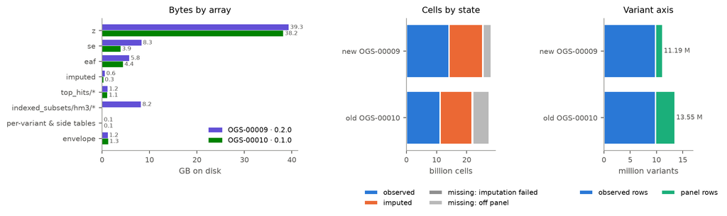

**Reading the size difference.** Of the new Store’s 64.69 GB, 8.20 GB is the HM3 Indexed Variant Subset. That is a derived query index (ADR 0061) the old Store does not carry. Without it the Stores are 56.49 GB against 49.33 GB. Three things make up that difference.

- **Content.** The new Store has 1.03x the cells (2,514 Analyses on 11.19 M variants, against 2,024 on 13.55 M). Its panel adds 1.34 M rows where the old one added 3.70 M, and fewer of its cells are empty: off-panel cells are 9.8% of the grid against 19.7%. An empty cell compresses to almost nothing, so a fuller grid costs more bytes per cell.
- **Format.** This comparison cannot isolate the format, because no other variable is held fixed. opengwas/opengwasdb#246 did isolate it: the same old observed OGS-00009 data, converted rather than rebuilt, took **34.68 GB** in the 0.1.0 shape and **35.17 GB** in the adopted 0.2.0 shape (1.014x; measured at `34b4ed1` on 2026-10-06). So the 0.2.0 layout itself accounts for about +1.4% of the size.
- **A codec setting.** Neither content nor layout: an estimated 2.83 GB of the new Store, from 200 sampled chunks, is its SE plane’s Blosc typesize (next callout).

Of the 7.16 GB gap without HM3, then, an estimated 2.83 GB is the codec setting, roughly 0.68 GB is the layout, and the remaining ~3.65 GB is content.

**WarningThe new OGS-00009’s `se` plane is compressed as if its cells were 4 bytes wide**

`se` is `int8` (1 byte per cell), but its Blosc codec records `typesize: 4`. Zarr v3 stores the typesize and Blosc bit-shuffles by it, so the bits of 4 neighbouring cells are interleaved rather than each cell’s own. Re-encoding 200 seeded inner chunks with the stored codec’s parameters takes **1.51x** the bytes at typesize 4 that it takes at typesize 1. Scaled by that ratio, the plane would be about 5.50 GB instead of 8.33 GB: an estimated **2.83 GB** of this Store, from 200 sampled chunks, is the codec setting. The values decode correctly; only the size is affected.

The cause is in the writer, not this Store. `opengwasdb.encoding.se._rewrite_arrays` creates the int8 SE plane, and its exception tables, with `compressor_of(source)`: the codec of the float32 scratch plane it replaces, whose typesize zarr has already fixed at 4. Zarr v2 took the typesize from the buffer at encode time, so 0.1.0 Stores never showed this, and any 0.2.0 Dense Store with residual-coded SE written this way will.

## Structure: format 0.2.0 against 0.1.0

Every Zarr array in each Store, read back from its own metadata (`compare_store_releases.discover_arrays`). A 0.1.0 array is Zarr v2 with one Blosc compressor and no shard. A 0.2.0 array is Zarr v3 whose Blosc codec sits inside `sharding_indexed`: the inner chunk is the read unit and the shard is the file.

| Array | new: shape, dtype | new: chunk / shard | new: format, codec | new GB | old: shape, dtype | old: chunk / shard | old: format, codec | old GB |
| --- | --- | --- | --- | --- | --- | --- | --- | --- |
| `eaf` | 11,191,070×2,514 int8 | 1,000×64 / 100,000×1,024 | v3, zstd 3, bitshuffle, typesize 1 in shard | 5.757 | 13,549,988×2,024 int8 | 1,000×1,000 / — | v2, zstd 3, bitshuffle | 4.440 |
| `eaf_baseline` | 11,191,070 float32 | 1,000 / 1,000,000 | v3, zstd 3, bitshuffle, typesize 4 in shard | 0.039 | 13,549,988 float32 | 1,000 / — | v2, zstd 3, bitshuffle | 0.044 |
| `eaf_exception_index` | 8,621 int64 | 8,621 / 8,621 | v3, sharding_indexed | 0.000 | 8,580 int64 | 8,580 / — | v2, | 0.000 |
| `eaf_exception_value` | 8,621 float32 | 8,621 / 8,621 | v3, sharding_indexed | 0.000 | 8,580 float32 | 8,580 / — | v2, | 0.000 |
| `eaf_reference` | 11,191,070 float32 | 1,000 / 1,000,000 | v3, zstd 3, bitshuffle, typesize 4 in shard | 0.039 | 13,549,988 float32 | 1,000 / — | v2, zstd 3, bitshuffle | 0.044 |
| `imputed` | 11,191,070×2,514 uint8 | 1,000×64 / 100,000×1,024 | v3, zstd 3, bitshuffle, typesize 1 in shard | 0.609 | 13,549,988×2,024 uint8 | 1,000×1,000 / — | v2, zstd 3, bitshuffle | 0.279 |
| `on_panel` | 11,191,070 uint8 | 1,000 / 1,000,000 | v3, zstd 3, bitshuffle, typesize 1 in shard | 0.002 | 13,549,988 uint8 | 1,000 / — | v2, zstd 3, bitshuffle | 0.002 |
| `se` | 11,191,070×2,514 int8 | 1,000×64 / 100,000×1,024 | v3, zstd 3, bitshuffle, typesize 4 in shard | 8.333 | 13,549,988×2,024 int8 | 1,000×1,000 / — | v2, zstd 3, bitshuffle | 3.910 |
| `se_coefficients` | 2,514×2 float32 | 1,024×2 / 3,072×2 | v3, zstd 3, bitshuffle, typesize 4 in shard | 0.000 | 2,024×2 float32 | 1,024×2 / — | v2, zstd 3, bitshuffle | 0.000 |
| `se_exception_index` | 1,680,419 int64 | 200,000 / 1,800,000 | v3, zstd 3, bitshuffle, typesize 4 in shard | 0.001 | 1,565,474 int64 | 200,000 / — | v2, zstd 3, bitshuffle | 0.001 |
| `se_exception_value` | 1,680,419 float32 | 200,000 / 1,800,000 | v3, zstd 3, bitshuffle, typesize 4 in shard | 0.003 | 1,565,474 float32 | 200,000 / — | v2, zstd 3, bitshuffle | 0.003 |
| `z` | 11,191,070×2,514 int16 | 1,000×64 / 100,000×1,024 | v3, zstd 3, bitshuffle, typesize 2 in shard | 39.333 | 13,549,988×2,024 int16 | 1,000×1,000 / — | v2, zstd 3, bitshuffle | 38.195 |
| `z_overflow_index` | 8,261 int64 | 8,261 / 8,261 | v3, sharding_indexed | 0.000 | 8,757 int64 | 8,757 / — | v2, | 0.000 |
| `z_overflow_value` | 8,261 float32 | 8,261 / 8,261 | v3, sharding_indexed | 0.000 | 8,757 float32 | 8,757 / — | v2, | 0.000 |
| `indexed_subsets/hm3/eaf` | 2,514×1,206,088 int8 | 1×65,536 / 1×1,048,576 | v3, zstd 3, bitshuffle, typesize 1 in shard | 0.772 | absent |  |  |  |
| `indexed_subsets/hm3/eaf_baseline` | 1,206,088 float32 | 65,536 / 983,040 | v3, zstd 3, bitshuffle, typesize 4 in shard | 0.004 | absent |  |  |  |
| `indexed_subsets/hm3/eaf_exception_index` | 1,042 int64 | 1,042 / 1,042 | v3, zstd 3, bitshuffle, typesize 8 in shard | 0.000 | absent |  |  |  |
| `indexed_subsets/hm3/eaf_exception_value` | 1,042 float32 | 1,042 / 1,042 | v3, zstd 3, bitshuffle, typesize 4 in shard | 0.000 | absent |  |  |  |
| `indexed_subsets/hm3/eaf_reference` | 1,206,088 float32 | 65,536 / 983,040 | v3, zstd 3, bitshuffle, typesize 4 in shard | 0.004 | absent |  |  |  |
| `indexed_subsets/hm3/imputed` | 2,514×1,206,088 uint8 | 1×65,536 / 1×1,048,576 | v3, zstd 3, bitshuffle, typesize 1 in shard | 0.195 | absent |  |  |  |
| `indexed_subsets/hm3/se` | 2,514×1,206,088 int8 | 1×65,536 / 1×1,048,576 | v3, zstd 3, bitshuffle, typesize 1 in shard | 1.207 | absent |  |  |  |
| `indexed_subsets/hm3/se_coefficients` | 2,514×2 float32 | 1,024×2 / 3,072×2 | v3, zstd 3, bitshuffle, typesize 4 in shard | 0.000 | absent |  |  |  |
| `indexed_subsets/hm3/se_exception_index` | 12,882 int64 | 12,882 / 12,882 | v3, zstd 3, bitshuffle, typesize 8 in shard | 0.000 | absent |  |  |  |
| `indexed_subsets/hm3/se_exception_value` | 12,882 float32 | 12,882 / 12,882 | v3, zstd 3, bitshuffle, typesize 4 in shard | 0.000 | absent |  |  |  |
| `indexed_subsets/hm3/variant_index` | 1,206,088 int32 | 65,536 / 983,040 | v3, zstd 3, bitshuffle, typesize 4 in shard | 0.001 | absent |  |  |  |
| `indexed_subsets/hm3/z` | 2,514×1,206,088 int16 | 1×65,536 / 1×1,048,576 | v3, zstd 3, bitshuffle, typesize 2 in shard | 6.017 | absent |  |  |  |
| `indexed_subsets/hm3/z_overflow_index` | 1,092 int64 | 1,092 / 1,092 | v3, zstd 3, bitshuffle, typesize 8 in shard | 0.000 | absent |  |  |  |
| `indexed_subsets/hm3/z_overflow_value` | 1,092 float32 | 1,092 / 1,092 | v3, zstd 3, bitshuffle, typesize 4 in shard | 0.000 | absent |  |  |  |
| `top_hits/p_5e_04/abs_z` | 48,044,899 float32 | 16,384 / 1,048,576 | v3, zstd 3, bitshuffle, typesize 4 in shard | 0.070 | 45,660,903 float32 | 16,384 / — | v2, zstd 3, bitshuffle | 0.068 |
| `top_hits/p_5e_04/analysis_index` | 48,044,899 uint32 | 16,384 / 1,048,576 | v3, zstd 3, bitshuffle, typesize 4 in shard | 0.000 | 45,660,903 uint32 | 16,384 / — | v2, zstd 3, bitshuffle | 0.000 |
| `top_hits/p_5e_04/analysis_offsets` | 2,515 uint64 | 2,515 / 2,515 | v3, zstd 3, bitshuffle, typesize 8 in shard | 0.000 | 2,025 uint64 | 2,025 / — | v2, zstd 3, bitshuffle | 0.000 |
| `top_hits/p_5e_04/eaf` | 48,044,899 float32 | 16,384 / 1,048,576 | v3, zstd 3, bitshuffle, typesize 4 in shard | 0.152 | 45,660,903 float32 | 16,384 / — | v2, zstd 3, bitshuffle | 0.145 |
| `top_hits/p_5e_04/imputed` | 48,044,899 uint8 | 16,384 / 1,048,576 | v3, zstd 3, bitshuffle, typesize 1 in shard | 0.004 | 45,660,903 uint8 | 16,384 / — | v2, zstd 3, bitshuffle | 0.005 |
| `top_hits/p_5e_04/p_value` | 48,044,899 float64 | 16,384 / 1,048,576 | v3, zstd 3, bitshuffle, typesize 8 in shard | 0.339 | 45,660,903 float64 | 16,384 / — | v2, zstd 3, bitshuffle | 0.321 |
| `top_hits/p_5e_04/se` | 48,044,899 float32 | 16,384 / 1,048,576 | v3, zstd 3, bitshuffle, typesize 4 in shard | 0.135 | 45,660,903 float32 | 16,384 / — | v2, zstd 3, bitshuffle | 0.131 |
| `top_hits/p_5e_04/variant_index` | 48,044,899 uint32 | 16,384 / 1,048,576 | v3, zstd 3, bitshuffle, typesize 4 in shard | 0.056 | 45,660,903 uint32 | 16,384 / — | v2, zstd 3, bitshuffle | 0.052 |
| `top_hits/p_5e_04/z` | 48,044,899 float32 | 16,384 / 1,048,576 | v3, zstd 3, bitshuffle, typesize 4 in shard | 0.076 | 45,660,903 float32 | 16,384 / — | v2, zstd 3, bitshuffle | 0.074 |
| `top_hits/p_5e_06/abs_z` | 12,817,911 float32 | 16,384 / 1,048,576 | v3, zstd 3, bitshuffle, typesize 4 in shard | 0.019 | 12,617,510 float32 | 16,384 / — | v2, zstd 3, bitshuffle | 0.019 |
| `top_hits/p_5e_06/analysis_index` | 12,817,911 uint32 | 16,384 / 1,048,576 | v3, zstd 3, bitshuffle, typesize 4 in shard | 0.000 | 12,617,510 uint32 | 16,384 / — | v2, zstd 3, bitshuffle | 0.000 |
| `top_hits/p_5e_06/analysis_offsets` | 2,515 uint64 | 2,515 / 2,515 | v3, zstd 3, bitshuffle, typesize 8 in shard | 0.000 | 2,025 uint64 | 2,025 / — | v2, zstd 3, bitshuffle | 0.000 |
| `top_hits/p_5e_06/eaf` | 12,817,911 float32 | 16,384 / 1,048,576 | v3, zstd 3, bitshuffle, typesize 4 in shard | 0.040 | 12,617,510 float32 | 16,384 / — | v2, zstd 3, bitshuffle | 0.040 |
| `top_hits/p_5e_06/imputed` | 12,817,911 uint8 | 16,384 / 1,048,576 | v3, zstd 3, bitshuffle, typesize 1 in shard | 0.001 | 12,617,510 uint8 | 16,384 / — | v2, zstd 3, bitshuffle | 0.001 |
| `top_hits/p_5e_06/p_value` | 12,817,911 float64 | 16,384 / 1,048,576 | v3, zstd 3, bitshuffle, typesize 8 in shard | 0.092 | 12,617,510 float64 | 16,384 / — | v2, zstd 3, bitshuffle | 0.090 |
| `top_hits/p_5e_06/se` | 12,817,911 float32 | 16,384 / 1,048,576 | v3, zstd 3, bitshuffle, typesize 4 in shard | 0.035 | 12,617,510 float32 | 16,384 / — | v2, zstd 3, bitshuffle | 0.036 |
| `top_hits/p_5e_06/variant_index` | 12,817,911 uint32 | 16,384 / 1,048,576 | v3, zstd 3, bitshuffle, typesize 4 in shard | 0.013 | 12,617,510 uint32 | 16,384 / — | v2, zstd 3, bitshuffle | 0.013 |
| `top_hits/p_5e_06/z` | 12,817,911 float32 | 16,384 / 1,048,576 | v3, zstd 3, bitshuffle, typesize 4 in shard | 0.020 | 12,617,510 float32 | 16,384 / — | v2, zstd 3, bitshuffle | 0.021 |
| `top_hits/p_5e_08/abs_z` | 6,439,000 float32 | 16,384 / 1,048,576 | v3, zstd 3, bitshuffle, typesize 4 in shard | 0.010 | 6,333,255 float32 | 16,384 / — | v2, zstd 3, bitshuffle | 0.010 |
| `top_hits/p_5e_08/analysis_index` | 6,439,000 uint32 | 16,384 / 1,048,576 | v3, zstd 3, bitshuffle, typesize 4 in shard | 0.000 | 6,333,255 uint32 | 16,384 / — | v2, zstd 3, bitshuffle | 0.000 |
| `top_hits/p_5e_08/analysis_offsets` | 2,515 uint64 | 2,515 / 2,515 | v3, zstd 3, bitshuffle, typesize 8 in shard | 0.000 | 2,025 uint64 | 2,025 / — | v2, zstd 3, bitshuffle | 0.000 |
| `top_hits/p_5e_08/eaf` | 6,439,000 float32 | 16,384 / 1,048,576 | v3, zstd 3, bitshuffle, typesize 4 in shard | 0.020 | 6,333,255 float32 | 16,384 / — | v2, zstd 3, bitshuffle | 0.020 |
| `top_hits/p_5e_08/imputed` | 6,439,000 uint8 | 16,384 / 1,048,576 | v3, zstd 3, bitshuffle, typesize 1 in shard | 0.001 | 6,333,255 uint8 | 16,384 / — | v2, zstd 3, bitshuffle | 0.001 |
| `top_hits/p_5e_08/p_value` | 6,439,000 float64 | 16,384 / 1,048,576 | v3, zstd 3, bitshuffle, typesize 8 in shard | 0.047 | 6,333,255 float64 | 16,384 / — | v2, zstd 3, bitshuffle | 0.046 |
| `top_hits/p_5e_08/se` | 6,439,000 float32 | 16,384 / 1,048,576 | v3, zstd 3, bitshuffle, typesize 4 in shard | 0.017 | 6,333,255 float32 | 16,384 / — | v2, zstd 3, bitshuffle | 0.018 |
| `top_hits/p_5e_08/variant_index` | 6,439,000 uint32 | 16,384 / 1,048,576 | v3, zstd 3, bitshuffle, typesize 4 in shard | 0.007 | 6,333,255 uint32 | 16,384 / — | v2, zstd 3, bitshuffle | 0.006 |
| `top_hits/p_5e_08/z` | 6,439,000 float32 | 16,384 / 1,048,576 | v3, zstd 3, bitshuffle, typesize 4 in shard | 0.011 | 6,333,255 float32 | 16,384 / — | v2, zstd 3, bitshuffle | 0.011 |

## Query time

Both Stores were timed by the generic store-comparison harness (`benchmarks/benchmark_store_comparison.py`), the same instrument opengwas/opengwasdb#240 and opengwas/opengwasdb#246 measured with. The selection was resolved once, before either Store was timed. It is recorded in `opengwasdb_ogs00009_vs_ogs00010_queries.json` under `selection`; that file’s sha256 is `9cedc30b21fb…`.

- The exposure is statin use (`ukb-b-17805`), and the PheWAS variant is `19:44908822:C:T` (APOE).
- The region is chr19:44.5–45.5 Mb, using only the 3,989 ALIDs both axes carry.
- The 100 random variants are drawn from the 10,740,157 ALIDs on both axes. The 100 random Analyses are drawn from the 2,024 shared Analyses.

**Not every shape is the same query on both Stores.**

- `bulk` reads one Analysis on each Store’s own axis: 9,975,895 against 11,229,918 results.
- `tophits` reads each Store’s own genome-wide hits: 2,960 against 3,488.
- Their observed-only twins nearly match: 7,578,648 against 7,578,651, and 2,564 against 2,564. They are the like-for-like timings.
- `phewas` and `regional` keep their historical meaning: every Analysis a Store holds. They therefore return wider results on the new Store. Their `_shared_analyses` and `_shared` twins ask both Stores the same question.

| Shape | new median | new warm range | new first call | new results | old median | old warm range | old first call | old results | new / old |
| --- | --- | --- | --- | --- | --- | --- | --- | --- | --- |
| Top hits, one Analysis (p < 5e-8) | **11.6 ms** | 11.4 ms–12.2 ms | 24.0 ms | 2,960 | **10.6 ms** | 9.5 ms–12.2 ms | 25.2 ms | 3,488 | 1.10x |
| Top hits, observed only | **11.1 ms** | 10.6 ms–11.5 ms | 10.2 ms | 2,564 | **10.0 ms** | 9.2 ms–10.9 ms | 10.5 ms | 2,564 | 1.11x |
| PheWAS, every Analysis | **45.3 ms** | 43.0 ms–48.0 ms | 52.1 ms | 2,514 | **24.6 ms** | 24.0 ms–25.8 ms | 26.2 ms | 2,020 | 1.84x |
| PheWAS, shared Analyses | **31.5 ms** | 30.5 ms–32.0 ms | 38.9 ms | 2,024 | **30.9 ms** | 28.6 ms–31.7 ms | 28.1 ms | 2,020 | 1.02x |
| Region, one Analysis | **45.9 ms** | 44.9 ms–90.7 ms | 44.0 ms | 3,610 | **69.6 ms** | 67.8 ms–94.5 ms | 66.4 ms | 3,308 | 0.66x |
| Lookup 10 variants × 100 Analyses | **306.1 ms** | 290.1 ms–312.6 ms | 295.6 ms | 999 | **106.9 ms** | 97.8 ms–108.9 ms | 110.5 ms | 809 | 2.86x |
| Lookup 100 variants × 10 Analyses | **1.08 s** | 1.02 s–1.12 s | 1.04 s | 914 | **527.1 ms** | 520.3 ms–571.2 ms | 532.2 ms | 785 | 2.05x |
| Region, every Analysis | **2.21 s** | 2.19 s–2.39 s | 2.74 s | 9,669,654 | **1.60 s** | 1.59 s–1.60 s | 1.52 s | 8,731,967 | 1.38x |
| Region, shared Analyses | **3.42 s** | 3.39 s–3.75 s | 3.36 s | 7,367,677 | **2.18 s** | 2.17 s–3.22 s | 2.08 s | 6,043,971 | 1.57x |
| One Analysis, genome-wide | **8.15 s** | 7.77 s–8.58 s | 10.94 s | 9,975,895 | **27.23 s** | 26.19 s–30.77 s | 31.64 s | 11,229,918 | 0.30x |
| One Analysis genome-wide, observed only | **7.76 s** | 7.72 s–7.79 s | 9.14 s | 7,578,648 | **26.79 s** | 26.00 s–30.99 s | 30.40 s | 7,578,651 | 0.29x |

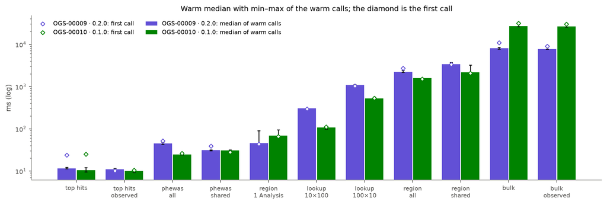

| Store | 1-min load, column start → end | 1-min load across its shapes | waited for load |
| --- | --- | --- | --- |
| OGS-00009 · 0.2.0 | 5.5 → 6.2 | 4.5–5.5 | 0 s |
| OGS-00010 · 0.1.0 | 6.2 → 5.3 | 3.8–6.2 | 0 s |

The harness times one Store’s column, then the next. Each column waited for the 1-minute load to fall below 48.0 before starting (the node has 224 cores and is shared with other builds), and every shape records the load average before and after it. Blosc decodes with 8 threads through zarr’s `FusedCodecPipeline` at `max_workers=1`, the package’s pinned reader. warm page cache: the node holds about 1 TB of page cache and the stores are warm. A cold-cache run cannot be forced without root, so these timings are warm-cache numbers, not first-touch disk numbers.

**What to make of the timings.** The format moves them most. The 1000×64 inner chunk makes one-Analysis reads over many variants (`bulk`, `regional_one_analysis`) much cheaper. Random lookups, and reads across every Analysis (`phewas`, `regional`), pay for more chunks. The indexed top-hit reads are close in both Stores. opengwas/opengwasdb#246 measured that effect on identical data; the same seven shapes are reproduced here from its artifact, so the format effect can be read without the content change:

| Shape | opengwas/opengwasdb#246 0.1.0 shape | opengwas/opengwasdb#246 0.2.0 shape | format only | this comparison (new / old) |
| --- | --- | --- | --- | --- |
| Top hits, one Analysis (p < 5e-8) | 7.5 ms | 11.2 ms | 1.50x | 1.10x |
| PheWAS, every Analysis | 16.6 ms | 45.8 ms | 2.75x | 1.84x |
| Region, one Analysis | 43.8 ms | 35.5 ms | 0.81x | 0.66x |
| Lookup 10 variants × 100 Analyses | 83.1 ms | 232.5 ms | 2.80x | 2.86x |
| Lookup 100 variants × 10 Analyses | 455.4 ms | 830.6 ms | 1.82x | 2.05x |
| Region, every Analysis | 884.3 ms | 1.19 s | 1.35x | 1.38x |
| One Analysis, genome-wide | 18.52 s | 6.48 s | 0.35x | 0.30x |

opengwas/opengwasdb#246: the old observed OGS-00009 converted to each shape, `34b4ed1`, 2026-10-06.

### Memory

Each shape runs in a fresh interpreter. The first number is RSS with the Store open before the query, the second is the peak sampled every 5 ms during it.

| Shape | OGS-00009 · 0.2.0 | OGS-00010 · 0.1.0 |
| --- | --- | --- |
| Top hits, one Analysis (p < 5e-8) | 181 → 182 MB (+2) | 178 → 180 MB (+1) |
| Top hits, observed only | 182 → 184 MB (+2) | 179 → 180 MB (+1) |
| PheWAS, every Analysis | 180 → 189 MB (+9) | 180 → 189 MB (+8) |
| PheWAS, shared Analyses | 181 → 189 MB (+8) | 179 → 189 MB (+11) |
| Region, one Analysis | 180 → 188 MB (+8) | 180 → 195 MB (+15) |
| Lookup 10 variants × 100 Analyses | 180 → 197 MB (+16) | 178 → 193 MB (+15) |
| Lookup 100 variants × 10 Analyses | 183 → 272 MB (+90) | 182 → 266 MB (+83) |
| Region, every Analysis | 180 → 1,367 MB (+1,187) | 178 → 1,209 MB (+1,031) |
| Region, shared Analyses | 180 → 1,545 MB (+1,365) | 181 → 933 MB (+752) |
| One Analysis, genome-wide | 180 → 1,264 MB (+1,084) | 179 → 1,369 MB (+1,190) |
| One Analysis genome-wide, observed only | 180 → 1,290 MB (+1,110) | 179 → 1,328 MB (+1,150) |

### HM3 extraction

The new Store publishes the HM3 Indexed Variant Subset (1,206,088 variants; 1,206,088 of 1,206,903 requested ALIDs resolved). Extracting `ukb-b-17805` from it takes **469.8 ms** (first call 450.0 ms, 1,193,015 cells), against 8.15 s for the whole Analysis genome-wide. The old Store has none (status `missing`: no Indexed Variant Subset named ‘hm3’ is published).

## MR positive controls

Each pair runs on each Store under three conditions:

- **all**: every instrument and outcome cell the Store holds;
- **observed**: `observed_only=True` throughout;
- **imputed**: instruments imputed in both the exposure and the outcome.

The method is unchanged from the OGS-00010 report: p < 5e-8, greedy 1 Mb pruning, then IVW. **Observed-only estimates measure the lift and the membership, not the panel**, and should agree. All and imputed estimates also carry the panel.

| Pair | Variants | new n | new beta | new se | new p | old n | old beta | old se | old p |
| --- | --- | --- | --- | --- | --- | --- | --- | --- | --- |
| BMI -> CHD (I25.1) | all | 616 | +0.0131 | 0.0009 | 2.8e-49 | 592 | +0.0133 | 0.0009 | 1.1e-49 |
|  | observed | 591 | +0.0132 | 0.0009 | 1.1e-48 | 591 | +0.0132 | 0.0009 | 1.1e-48 |
|  | imputed | 462 | +0.0125 | 0.0010 | 1e-34 | 487 | +0.0125 | 0.0010 | 4e-36 |
| LDL proxy (cholesterol-lowering medication) -> CHD (I25.1) | all | 38 | +0.1448 | 0.0063 | 1.8e-115 | 35 | +0.1475 | 0.0065 | 5.6e-114 |
|  | observed | 34 | +0.1497 | 0.0066 | 2.3e-115 | 34 | +0.1497 | 0.0066 | 2.3e-115 |
|  | imputed | 26 | +0.1275 | 0.0075 | 1.2e-65 | 25 | +0.1274 | 0.0073 | 7.6e-68 |
| Past tobacco smoking -> lung cancer (C34.1) | all | 108 | -0.0012 | 0.0005 | 0.022 | 106 | -0.0013 | 0.0005 | 0.015 |
|  | observed | 54 | -0.0016 | 0.0007 | 0.028 | 54 | -0.0016 | 0.0007 | 0.028 |
|  | imputed | 59 | -0.0028 | 0.0007 | 7.9e-05 | 68 | -0.0022 | 0.0007 | 0.00091 |

| Observed-only check | new beta (n) | old beta (n) | agree to (significant figures) | same sign | same significance (p < 0.05) |
| --- | --- | --- | --- | --- | --- |
| bmi_chd | +0.0132158 (591) | +0.013216 (591) | 5 | yes | yes |
| ldl_chd | +0.149716 (34) | +0.149722 (34) | 5 | yes | yes |
| smoking_lung | -0.00164185 (54) | -0.00164168 (54) | 4 | yes | yes |

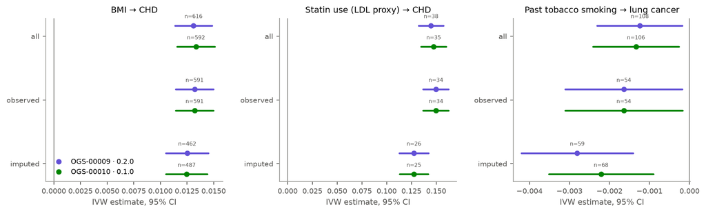

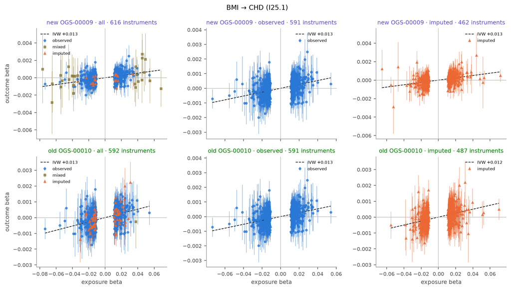

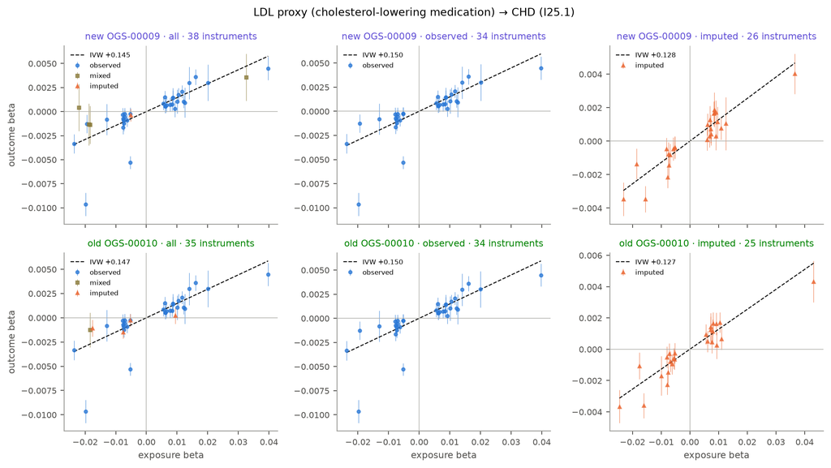

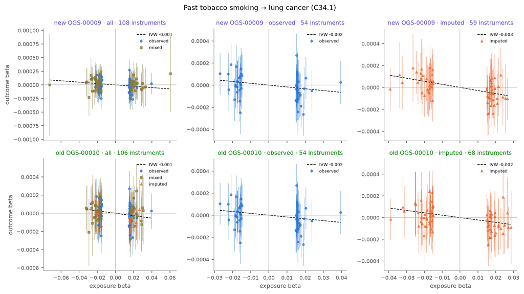

**NoteTwo of the three pairs are proxies (unchanged from the OGS-00010 report)**

ukb-b has no LDL biomarker, so the “LDL” exposure is statin use, which is confounded by indication. It also has no lung-cancer incidence trait: the outcome is the ICD-10 C34.1 cancer-site field, which is coded only among cancer cases, so it is a collider endpoint. These pairs check the pipeline and the Stores against each other. They are not causal estimates.

## Regional profiles

Each window shows one exposure’s −log10 p over every variant of each Store’s axis, side by side.

- Points are coloured by provenance: **observed**, **imputed** at a variant of the observed axis, and **panel** (imputed at a panel-only row that completion added). Variants that are still missing are ticks on the floor.
- The windows are centred on each exposure’s strongest imputed genome-wide hit in each Store. The APOE window (chr19:44.5–45.5 Mb) is added for statin use.

The observed points are the same data in both Stores, apart from the variants the lift renamed. The imputed and panel points differ because the panels differ.

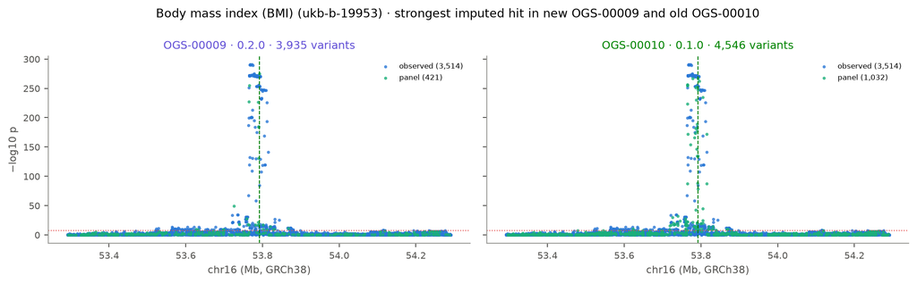

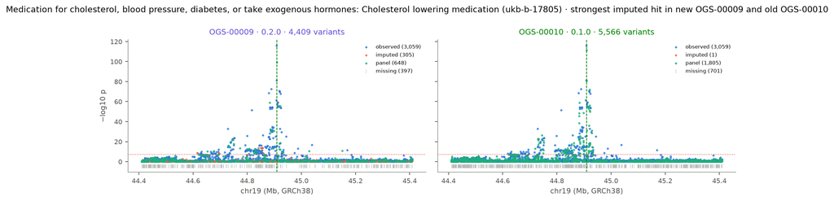

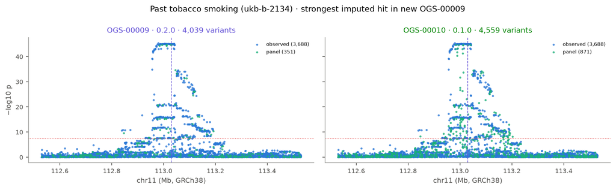

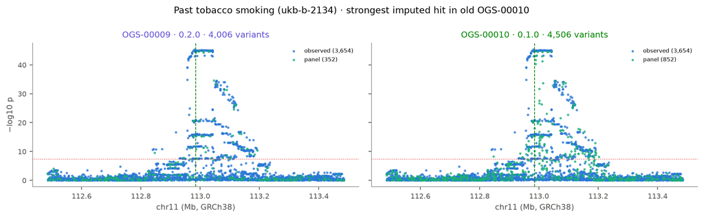

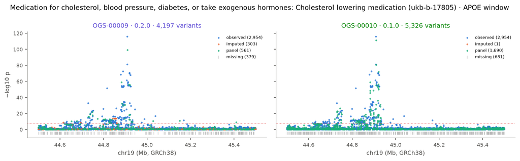

| Window | Centre | new: observed / imputed / panel / missing | old: observed / imputed / panel / missing |
| --- | --- | --- | --- |
| Body mass index (BMI) (`ukb-b-19953`), chr16:53.29–54.29 Mb | new OGS-00009: `16:53791993:A:G` z=+35.5; old OGS-00010: `16:53791993:A:G` z=+35.0 | 3,514 / 0 / 421 / 0 | 3,514 / 0 / 1,032 / 0 |
| Medication for cholesterol, blood pressure, diabetes, or take exogenous hormones: Cholesterol lowering medication (`ukb-b-17805`), chr19:44.41–45.41 Mb | new OGS-00009: `19:44909976:G:T` z=+21.2; old OGS-00010: `19:44909976:G:T` z=+22.5 | 3,059 / 305 / 648 / 397 | 3,059 / 1 / 1,805 / 701 |
| Past tobacco smoking (`ukb-b-2134`), chr11:112.53–113.53 Mb | new OGS-00009: `11:113030063:T:TA` z=-14.1 | 3,688 / 0 / 351 / 0 | 3,688 / 0 / 871 / 0 |
| Past tobacco smoking (`ukb-b-2134`), chr11:112.48–113.48 Mb | old OGS-00010: `11:112984949:A:AT` z=-14.1 | 3,654 / 0 / 352 / 0 | 3,654 / 0 / 852 / 0 |
| Medication for cholesterol, blood pressure, diabetes, or take exogenous hormones: Cholesterol lowering medication (`ukb-b-17805`), chr19:44.50–45.50 Mb | fixed window | 2,954 / 303 / 561 / 379 | 2,954 / 1 / 1,690 / 681 |

## Build collisions

When the hg19 → hg38 lift puts two source variants on one ALID, `build-dense-vcf` writes both into that ALID’s row. The row keeps one rsid and one source’s statistics, and its `source_alid` is blanked as ambiguous. Nothing fails: `validate` and the observed-view check both pass ([opengwas/opengwasdb#325](https://github.com/opengwas/opengwasdb/issues/325)).

This section reads each Store on its own, because a collision both Stores share is invisible to any comparison between them.

- Rows are the blank `source_alid`s of the Store’s observed-only parent, each confirmed on the published completed axis under the same rsid.
- Sources are the source GWAS-VCF’s records that the Store’s own lift puts on the ALID.
- Whose statistics the row holds is decided by comparing the stored z with each source’s z, in ukb-b-17805 and ukb-b-19953.

### OGS-00009 · 0.2.0: 8 rows × 2,514 Analyses = 20,112 cells

Lift: installed package: its lift files are blob-identical to d405de0’s. In 7 of 8 rows, the rsid names a different source from the one whose statistics the row holds.

| Row | rsid | hg19 sources (chain strand) | Statistics held | In the other Store | Observed cells |
| --- | --- | --- | --- | --- | --- |
| `4:74450339:C:T` | rs368667736 | `4:75316056:C:T` rs368667736 (+); `4:75485813:C:T` rs2291714 (+) | **`4:75485813:C:T`** rs2291714 ⚠ rsid names the other source | collision in both: old OGS-00010 has it (rs368667736) | 2,230 |
| `7:74988062:G:T` | rs35525401 | `7:74402206:G:T` rs35525401 (+); `7:74844193:C:A` rs868975575 (-) | **`7:74844193:C:A`** rs868975575 ⚠ rsid names the other source | **new collision**: old OGS-00010 held it uncollided (rs35525401) | 2,030 |
| `7:75044656:A:C` | rs587647277 | `7:74458765:C:A` rs587647277 (+); `7:74787650:G:T` rs4517039 (-) | **`7:74787650:G:T`** rs4517039 ⚠ rsid names the other source | **new collision**: old OGS-00010 held it uncollided (rs587647277) | 1,292 |
| `7:75044656:C:G` | rs587647277 | `7:74458765:C:G` rs587647277 (+); `7:74787650:G:C` rs4517039 (-) | **`7:74787650:G:C`** rs4517039 ⚠ rsid names the other source | collision in both: old OGS-00010 has it (rs4517039) | 1,292 |
| `7:101668260:A:G` | rs200217321 | `19:7323129:T:C` rs200217321 (-); `7:101311540:A:G` rs848673 (+) | **`19:7323129:T:C`** rs200217321 | **new collision**: old OGS-00010 held it uncollided (rs848673) | 2,514 |
| `8:144235357:C:T` | rs11992210 | `8:145290260:C:T` rs11992210 (+); `8:145459313:C:T` 8_145459313_C_T (+) | **`8:145459313:C:T`** 8_145459313_C_T ⚠ rsid names the other source | collision in both: old OGS-00010 has it (rs11992210) | 2,514 |
| `10:47013158:A:G` | rs373336509 | `10:46539289:C:T` rs373336509 (-); `10:48726204:C:T` rs4926052 (-) | **`10:48726204:C:T`** rs4926052 ⚠ rsid names the other source | collision in both, renamed by opengwas/opengwasdb#288: old OGS-00010 has it as `10:47013158:C:T` (rs4926052) | 2,432 |
| `10:50240776:C:T` | rs200903336 | `10:52000536:T:C` rs7902744 (+); `10:48055247:T:C` rs200903336 (+) | **`10:52000536:T:C`** rs7902744 ⚠ rsid names the other source | collision in both: old OGS-00010 has it (rs200903336) | 2,514 |

### OGS-00010 · 0.1.0: 5 rows × 2,024 Analyses = 10,120 cells

Lift: git archive of opengwasdb/build/liftover.py at f8125322f9d9b71db8b05d1c18d507612bf654e2. In 3 of 5 rows, the rsid names a different source from the one whose statistics the row holds.

| Row | rsid | hg19 sources (chain strand) | Statistics held | In the other Store | Observed cells |
| --- | --- | --- | --- | --- | --- |
| `4:74450339:C:T` | rs368667736 | `4:75316056:C:T` rs368667736 (+); `4:75485813:C:T` rs2291714 (+) | **`4:75485813:C:T`** rs2291714 ⚠ rsid names the other source | collision in both: new OGS-00009 has it (rs368667736) | 1,803 |
| `7:75044656:C:G` | rs4517039 | `7:74458765:C:G` rs587647277 (+); `7:74787650:G:C` rs4517039 (-) | **`7:74787650:G:C`** rs4517039 | collision in both: new OGS-00009 has it (rs587647277) | 1,046 |
| `8:144235357:C:T` | rs11992210 | `8:145290260:C:T` rs11992210 (+); `8:145459313:C:T` 8_145459313_C_T (+) | **`8:145459313:C:T`** 8_145459313_C_T ⚠ rsid names the other source | collision in both: new OGS-00009 has it (rs11992210) | 2,024 |
| `10:47013158:C:T` | rs4926052 | `10:46539289:C:T` rs373336509 (-); `10:48726204:C:T` rs4926052 (-) | **`10:48726204:C:T`** rs4926052 | collision in both, renamed by opengwas/opengwasdb#288: new OGS-00009 has it as `10:47013158:A:G` (rs373336509) | 1,967 |
| `10:50240776:C:T` | rs200903336 | `10:52000536:T:C` rs7902744 (+); `10:48055247:T:C` rs200903336 (+) | **`10:52000536:T:C`** rs7902744 ⚠ rsid names the other source | collision in both: new OGS-00009 has it (rs200903336) | 2,024 |

**The class predates opengwas/opengwasdb#288.** Of the new Store’s 8 collisions, 5 are carried over from the old Store and 3 are new: opengwas/opengwasdb#288’s complement lands a renamed reverse-strand variant on an ALID another source already holds. 3 of the 3 new ones sit at an ALID the old Store held uncollided, so a lookup that used to return that variant’s own association now returns another variant’s: `7:74988062:G:T` was rs35525401 and now holds `7:74844193:C:A`’s statistics under rs35525401; `7:75044656:A:C` was rs587647277 and now holds `7:74787650:G:T`’s statistics under rs587647277; `7:101668260:A:G` was rs848673 and now holds `19:7323129:T:C`’s statistics under rs200217321. 0 of the old Store’s collisions are gone. Every row holds exactly one source’s statistics: a lookup returns that source’s association at the position, and the other source’s is lost. The cross-Store view of the 3 new collisions (`lift_axis.collapsed`) points here.

## Observed-cell fidelity

This section asks whether the two Stores hold the same observed cells. A cell is an Analysis × variant pair, matched by ALID, over the 2,024 shared Analyses. Every observed cell of the old Store gets exactly one category:

- **identical:** z bit-identical; SE and EAF within the encoding’s tolerance (below).
- **(a) re-oriented by opengwas/opengwasdb#288:** a palindromic SNP the chain lifts through a reverse-strand block, decided from the chain alone. Its ALID is unchanged, z is exactly negated, EAF becomes 1 − EAF, and SE is unchanged.
- **(b) present in only one Store:** opengwas/opengwasdb#288 *renamed* the variant (its alleles complemented), and its cells reappear, re-oriented, under the new spelling.
- **(d) build collision:** the row is a build collision in either Store, or lands on one, so it holds one of two sources’ statistics ([opengwas/opengwasdb#325](https://github.com/opengwas/opengwasdb/issues/325)).
- **palindrome, strand ambiguous:** a palindrome whose hg19 source the chain maps both ways. It is counted apart from (a), and only when one orientation holds.
- **(c) unexplained:** anything else, including a variant that is gone with no lift evidence for why. Any cell here stops the benchmark run.

A new observed cell that no old cell accounts for is (d) at a collision row and (c) anywhere else.

### What the lift did, exhaustively

| Observed axis | Count |
| --- | --- |
| Old observed variants | 9,847,701 |
| New observed variants | 9,847,698 |
| Shared (same ALID) | 9,838,278 |
| Only in old / only in new | 9,423 / 9,420 |
| Renamed pairs (complemented alleles, same position) | 9,420 |
| of which the package’s own lift reproduces | 9,420 |
| of which swap the canonical allele (z negated, EAF flipped) | 9,420 |
| Renamed onto an ALID the new Store already held (a new build collision) | 3 (lift reproduces 3) |
| Dropped (no counterpart) / new without a counterpart | 0 / 0 |
| One-sided variants outside any reverse-strand chain block | 0 |
| Shared variants under a reverse-strand block | 2,381 |
| palindromes only under reverse blocks: re-oriented | 1,850 |
| palindromes under both orientations, source lifts in reverse: re-oriented | 11 |
| palindromes under both orientations, source lifts forward: unchanged | 51 |
| palindromes under both orientations, chain cannot decide | 0 |
| palindromes under both orientations, a build-collision row | 1 |
| non-palindromes also under a forward block: unchanged | 468 |
| non-palindromes only under reverse blocks (should not exist) | 0 |
| **Re-oriented by opengwas/opengwasdb#288, in all** | **1,861** (lift reproduces 1,861) |

The two observed axes were compared in full: every variant of each parent’s variant table. Which chain block each variant lies under is read from the hg19 → hg38 chain (hg19ToHg38.over.chain.gz, sha256 5c0598e500ce…).

- A rename or a reverse-only palindrome counts as reproduced when the package’s own `lifted_rows` takes the old spelling, read back to hg19 through the reverse block, to the new spelling on the reverse strand.
- A palindrome under blocks of both orientations is decided by lifting its hg19 `source_alid` (from the old parent) through the chain, never by which orientation its cells fit.

The run stops if any reproduction falls short, or if a variant only one Store carries lies outside every reverse-strand block.

### Cells

| Stratum / category | Variants | Cells |
| --- | --- | --- |
| **Seeded random windows** | 500,004 variants | **579,763,142** old observed cells |
| identical | 499,004 | 578,652,192 |
| (a) re-oriented | 148 | 162,327 |
| (b) present in only one Store (renamed) | 851 | 946,656 |
| (d) build collision | 1 | 1,967 |
| (d) build collision, observed only in new | 0 | 0 |
| palindrome, strand ambiguous | 0 | 0 |
| (c) unexplained | 0 | 0 |
| (c) observed only in new | 0 | 0 |
| of the (d) cells, reproduced by the other Store |  | 1,967 |
| **Every observed variant the lift could touch, and every collision row** | 11,807 variants | **14,190,874** old observed cells |
| identical | 516 | 687,863 |
| (a) re-oriented | 1,861 | 2,214,318 |
| (b) present in only one Store (renamed) | 9,419 | 11,270,573 |
| (d) build collision | 11 | 18,120 |
| (d) build collision, observed only in new | 0 | 0 |
| palindrome, strand ambiguous | 0 | 0 |
| (c) unexplained | 0 | 0 |
| (c) observed only in new | 0 | 0 |
| of the (d) cells, reproduced by the other Store |  | 12,529 |

**“Of the (d) cells, reproduced by the other Store”** counts the (d) cells whose counterpart in the new Store agrees with the old cell, re-oriented where the lift implies. It is informative, not a verdict. A collision both Stores share and resolve to the same source reproduces; a collision that keeps the other source in one Store does not, and nor does the cell of the source a collision dropped.

**How large the sample is.** The seeded stratum draws 1,000 non-overlapping windows of 500 consecutive old observed variants (seed 20261024), giving 500,004 variants. That is 5.1% of the old observed axis, and 579,763,142 observed cells across all 2,024 shared Analyses. Each window is read by position on both Stores, so a variant only one Store spells that way is inside it too. With none unexplained, the rule of three bounds the rate of variants carrying an unexplained difference below 6.0e-06 (95%). The second stratum is not a sample: it covers every observed variant the lift could have touched and every build-collision row of either Store.

| Identical cells | z bit-identical | SE bit-identical | EAF bit-identical | max \|Δ log SE\| | max \|Δ logit EAF\| |
| --- | --- | --- | --- | --- | --- |
| Seeded random windows | 100.0% | 11.4% | 72.9% | 0.003937 | 0.003942 |
| Every observed variant the lift could touch, and every collision row | 100.0% | 14.0% | 74.7% | 0.003937 | 0.003953 |

**Why SE and EAF are compared with a tolerance.** z is `int16_fixed`, an exact code, so it is compared bit for bit and matches in every identical cell. SE and EAF are `int8_residual`: each Store codes a value as a residual against its own baseline, and the baselines move with membership. The EAF baseline is the median over a Store’s Analyses. So each Store decodes within half a quantisation step of the source value, and two Stores can differ by up to one step: 0.003938 in log SE and 0.003938 in logit EAF. A frequency also carries float32 rounding, which near 0 or 1 adds up to 2 * 2^-24 / min(f, 1 - f) to its logit. That matters for the rare variants the lift flipped close to 1. The widest gaps above sit right at that bound. Any real difference is far larger: a wrong orientation moves the logit by 2 |logit(f)|.

## Caveats

- **Both Stores carry build collisions.** 8 rows × 2,514 Analyses (20,112 cells, 16,818 observed) in the new OGS-00009, and 5 rows × 2,024 Analyses (10,120 cells, 8,864 observed) in the old OGS-00010, hold one of two colliding source variants’ statistics (opengwas/opengwasdb#325). A lookup of one of these rows returns one source’s association, often under the other source’s rsid, with no warning. The fidelity check counts their cells as (d), apart from (c). Its “0 unexplained” holds only beside them.
- **Imputed cells differ because the panels differ.** UKB EUR LD against HGDP+1KGP EUR. The two Stores’ imputed values, panel rows, regional imputed points and the all- and imputed-condition MR estimates are not expected to agree, and no section treats a difference there as a defect. Only observed cells are held to identity.
- **Timings come from a shared host.** The node runs other builds. Each Store’s column waited for the 1-minute load to fall below the gate, and every shape records its load average, but the columns ran one after the other, so a load change between them lands on one Store. The page cache is warm and uncontrolled: “first call” means the shape’s first call, not a cold disk read.
- **Format and content are not separated here.** The new Store is bigger and differently shaped. The opengwas/opengwasdb#246 reference rows (the same data in both shapes) are where the format effect alone can be read.
- **The fidelity check is by ALID.** It examines the shared Analyses only. The 490 added Analyses have no counterpart to compare.
- **The panel provenance comes from step records, not the manifest.** See the warning under *The two Stores*.
- **Two MR pairs are proxies**, as flagged above.

**Lookup timings moved between this report’s runs, on the new Store only.** PheWAS on the new Store took 25.0 ms in round 0 (backup/r0-bench-ogs00009-vs-ogs00010) and 45.3 ms in this run. The old Store went from 23.9 ms to 24.6 ms. The two runs’ warm ranges on the new Store do not overlap: 24.3 ms–27.4 ms against 43.0 ms–48.0 ms. So the within-run spread understates lookup-time uncertainty on a shared host. Read the medians below as one draw each.

| Run | commit | new: phewas | old: phewas | new: phewas, shared | old: phewas, shared | new: lookup 10×100 | old: lookup 10×100 |
| --- | --- | --- | --- | --- | --- | --- | --- |
| round 0 (backup/r0-bench-ogs00009-vs-ogs00010) | `e4e9723` | 25.0 ms (24.3 ms–27.4 ms) | 23.9 ms (22.9 ms–25.3 ms) | 38.3 ms (35.2 ms–40.4 ms) | 28.7 ms (27.5 ms–30.5 ms) | 285.8 ms (284.2 ms–305.5 ms) | 106.0 ms (101.3 ms–108.7 ms) |
| round 1 (backup/r1-bench-ogs00009-vs-ogs00010) | `ca15600` | 50.2 ms (42.5 ms–52.7 ms) | 21.7 ms (20.1 ms–24.8 ms) | 54.6 ms (52.0 ms–57.2 ms) | 25.8 ms (23.6 ms–27.7 ms) | 301.6 ms (285.8 ms–304.1 ms) | 96.0 ms (92.2 ms–100.6 ms) |
| this run | `3efc3b9` | 45.3 ms (43.0 ms–48.0 ms) | 24.6 ms (24.0 ms–25.8 ms) | 31.5 ms (30.5 ms–32.0 ms) | 30.9 ms (28.6 ms–31.7 ms) | 306.1 ms (290.1 ms–312.6 ms) | 106.9 ms (97.8 ms–108.9 ms) |

Earlier runs are read from their own committed query-time artifacts (`earlier_runs`, with each file’s sha256).

Measured at `3efc3b9` on 2026-10-24T14:31:02 UTC (opengwasdb fingerprint `dd4e98d392f8`). The benchmark ran for 27.6 min in total identity 0.0 min, axes and lift 1.9 min, fidelity 10.1 min, build collisions 0.5 min, mr 0.2 min, regions 0.0 min, structure 0.1 min, queries 14.7 min. Load average 8.2 at the start, 5.2 at the end.